# Dynamics of group discussion in agreement-error space

Lingyu Meng, Tom Stafford

2023-11-10

# Group Discussion

Group discussion has the power to change the opinions of those taking part. Individuals may move so they agree with each other more, or less, and they may move so they are move, or less, accurate.

To visualise the effect of group discussion on these two dimensions - agreement and error - we take data from a forecasting experiment which collected pre and post discussion answers from individuals in small groups:

- Silver, I., Mellers, B.A. and Tetlock, P.E. (2021) ‘Wise teamwork: Collective confidence calibration predicts the effectiveness of group discussion’, *Journal of Experimental Social Psychology*, 96, p. 104157. https://doi.org/10.1016/j.jesp.2021.104157

Silver, Mellers and Tetlock (2021) found that group interactions were likelier to yield increased accuracy if more accurate members were more confident in their own judgment and less accurate members less confident. By visuialising how the discussions change individuals answers we can see how different kinds of groups contribute to these effects.

# Visualising how discussion moves individual’s answers

We use an arrow to represent the pre and post discussion scores of each group. Each group has multiple discussions and each discussion is shown with a single arrow

The y-axis shows Error, which is a z-score (normalised at a question level) of the absolute difference value between the average answer of the individuals in the group and the correct answer. Higher scores are worse performance.

The x-axis shows Disagreement, which is z-score (normalised at a question level) of standard deviation of the answers of the individuals in the groups. Higher scores are more disagreement (variance) among the group in their answers.

. In other word, we have an arrow for each group in every question, form point1 to point2: point1 = (Deviation_Time1, Error_Time1) point2 = (Deviation_Time2, Error_Time2)

```r
library("tidyverse")
library("cowplot")
```

```r
#get data from https://osf.io/a4cf7/?action=download",destfile="data1.csv")

group_data <- read_csv("data1.csv")
group_data <- mutate(group_data, agree = sd2 < sd1) # create a new variable to indicate whether group agreement formed
```

```r
group_data_n <- group_data %>%
  pivot_longer(cols = 8:9,   names_to ="acc_time", values_to = "acc_val") %>%
  pivot_longer(cols = 12:13, names_to ="agr_time", values_to = "agr_val") %>%
  group_by(qcode) %>%
  mutate(acc_val = scale(acc_val), agr_val = scale(agr_val)) %>%
  pivot_wider(names_from = "acc_time", values_from = "acc_val") %>%
  pivot_wider(names_from = "agr_time", values_from = "agr_val") %>%
  mutate(agree = as.factor(agree), improve = as.factor(improve)) %>%
  ungroup(qcode)
```

We look only at Silver, Mellers & Tetlock (2021), study 1. Showing all groups and all questions:

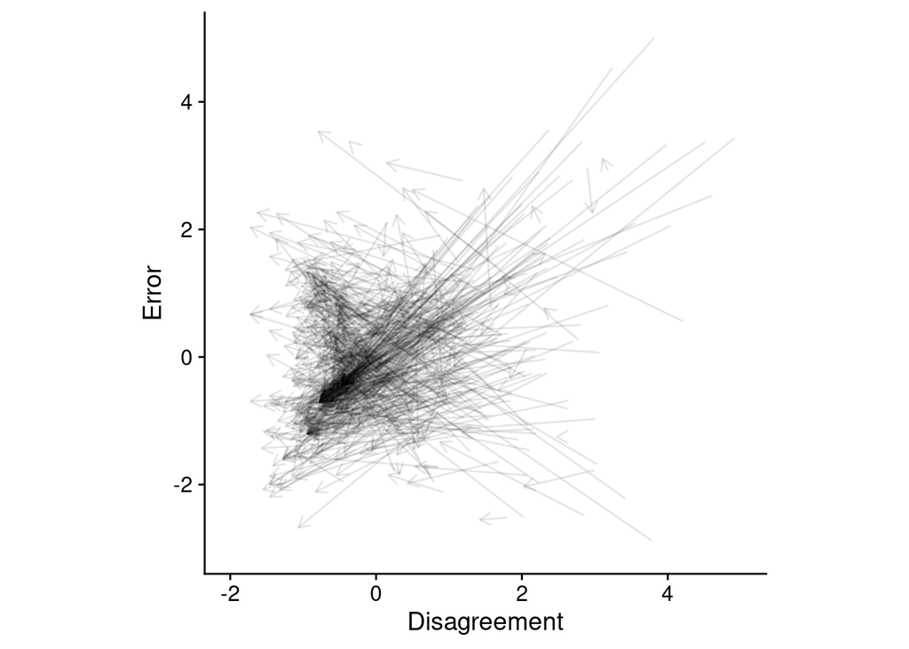

Figure 1: Movement of each group pre/post discussion, in normalised diagreement-error space

```r
arrow_graph_n <- ggplot() +
  geom_segment(aes(x = sd1, y = aee1, xend = sd2, yend = aee2), data = group_data_n, arrow = arrow(length=unit(0.1,"inches")), alpha = 0.1) +
  theme_cowplot() + xlab('Disagreement') + ylab('Error') + ylim(-3, 5) + xlim(-2, 5) + theme(aspect.ratio=1)
```

## Converging vs diverging discussions

Now we show the average movement for two kinds of discussions: those where disagreement reduced (the group’s answers converged) vs those where diagreenebt increased (the group’s answers diverged). The arrow thickness represents the number of dicussions in each category:

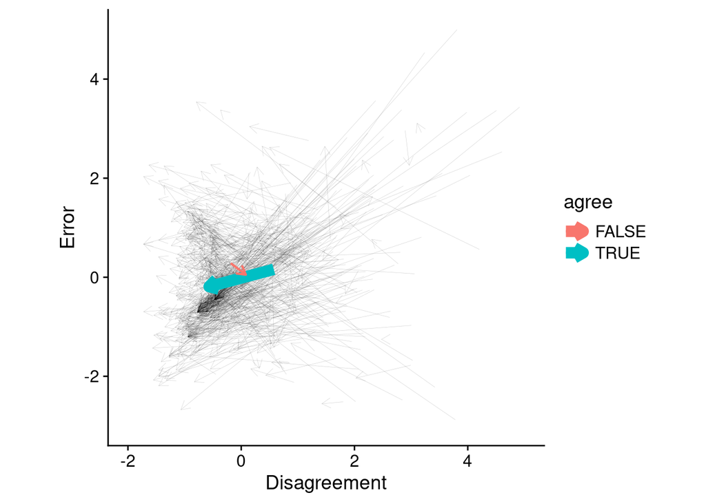

Figure 2: Movement of each group pre/post discussion, in normalised diagreement-error space, highlighting average movement for groups which agree more vs less following discussion

```r
averaged_data_n <- group_data_n %>%
  select(sd1, sd2, aee1, aee2, agree) %>%
  group_by(agree) %>%
  summarise(sd1 = mean(sd1), sd2 = mean(sd2), aee1 = mean(aee1), aee2 = mean(aee2), case = n()/100)
line_thickness <- averaged_data_n %>% select(case) %>% unlist() %>% as.vector() # don't mapping thickness by aes(size = x)

arrow_graph_agree_n_average <- ggplot() +
  geom_segment(aes(x = sd1, y = aee1, xend = sd2, yend = aee2), data = group_data_n, arrow = arrow(length=unit(0.1,"inches")), alpha = 0.2, size = 0.1) +
  geom_segment(aes(x = sd1, y = aee1, xend = sd2, yend = aee2, colour = agree), data = averaged_data_n %>% filter(agree == 'TRUE'), arrow = arrow(length=unit(0.1,"inches")), alpha = 1, lwd = (line_thickness[2]+1)/avg_scale) +
  geom_segment(aes(x = sd1, y = aee1, xend = sd2, yend = aee2, colour = agree), data = averaged_data_n %>% filter(agree == 'FALSE'), arrow = arrow(length=unit(0.1,"inches")), alpha = 1, lwd = (line_thickness[1]+1)/avg_scale) +
  theme_cowplot() + xlab('Disagreement') + ylab('Error') + ylim(-3, 5) + xlim(-2, 5) + guides(size = "none") + theme(aspect.ratio=1)
```

## Error increasing or reducing discussions

Now we show the average movement for two kinds of discussions: those where individual’s answers became more accurate vs those where individual’s answers became less accurate. The arrow thickness represents the number of discussions in each category:

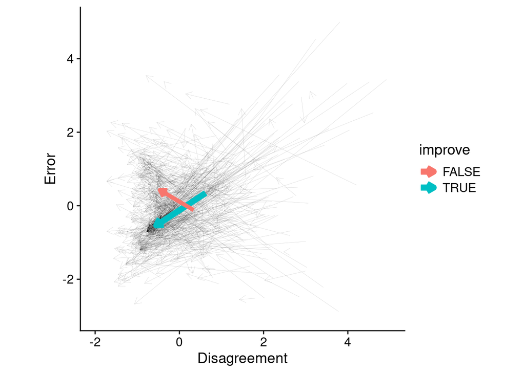

Figure 3: Movement of each group pre/post discussion, in normalised diagreement-error space, highlighting average movement for groups which improve or degrade in accruacy following discussion

```r
averaged_data_n <- group_data_n %>%
  select(sd1, sd2, aee1, aee2, improve) %>%
  group_by(improve) %>%
  summarise(sd1 = mean(sd1), sd2 = mean(sd2), aee1 = mean(aee1), aee2 = mean(aee2), case = n()/100)

line_thickness <- averaged_data_n %>% select(case) %>% unlist() %>% as.vector() # assign thickness of arrows by case numbers

levels(averaged_data_n$improve) <- c("FALSE", "TRUE") # rename improvement level

arrow_graph_improve_n_average <- ggplot() +
  geom_segment(aes(x = sd1, y = aee1, xend = sd2, yend = aee2), data = group_data_n, arrow = arrow(length=unit(0.1,"inches")), alpha = 0.2, size = 0.1) +
  geom_segment(aes(x = sd1, y = aee1, xend = sd2, yend = aee2, colour = improve), data = averaged_data_n %>% filter(improve == 'TRUE'), arrow = arrow(length=unit(0.1,"inches")), alpha = 1, lwd = (line_thickness[2]+1)/avg_scale) +
  geom_segment(aes(x = sd1, y = aee1, xend = sd2, yend = aee2, colour = improve), data = averaged_data_n %>% filter(improve == 'FALSE'), arrow = arrow(length=unit(0.1,"inches")), alpha = 1, lwd = (line_thickness[1]+1)/avg_scale,) +
  theme_cowplot() + xlab('Disagreement') + ylab('Error') + ylim(-3, 5) + xlim(-2, 5) + guides(size = "none") + theme(aspect.ratio=1)
```

We can see that group usually moved towards each other (670 agree vs 57 disagree), but also regardless of convergence/divergence their average performance improved.

Split by error, many groups didn’t improved their performance (451 improve vs 276 degrade).

Looking at Figure 2, the arrow of positive agreement group is much longer than negative agreement group, which supports the idea that group dynamics support consensus over polarisation (along with there being more groups which agreed than disagreed).

Looking at Figure 3, the longer arrow for improving discussions perhaps suggests that agreement supports error reduction.

## Additional plots

We colour the arrows by the two kind of class to show how they changed their answer.

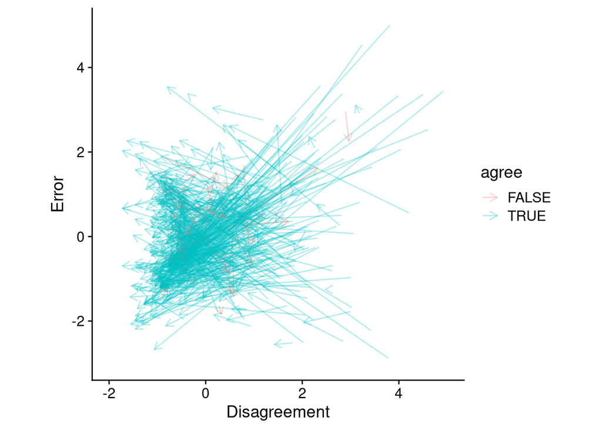

Figure 4: Movement of each group pre/post discussion, in normalised diagreement-error space, highlighting groups which agree more vs less following discussion

```r
levels(group_data_n$improve) <- c("FALSE", "TRUE") # rename improvement level

arrow_graph_agree_n <- ggplot() +
  geom_segment(aes(x = sd1, y = aee1, xend = sd2, yend = aee2, colour = agree), data = group_data_n, arrow = arrow(length=unit(0.1,"inches")), alpha = 0.3) +
  theme_cowplot() + xlab('Disagreement') + ylab('Error') + ylim(-3, 5) + xlim(-2, 5) + theme(aspect.ratio=1)
```

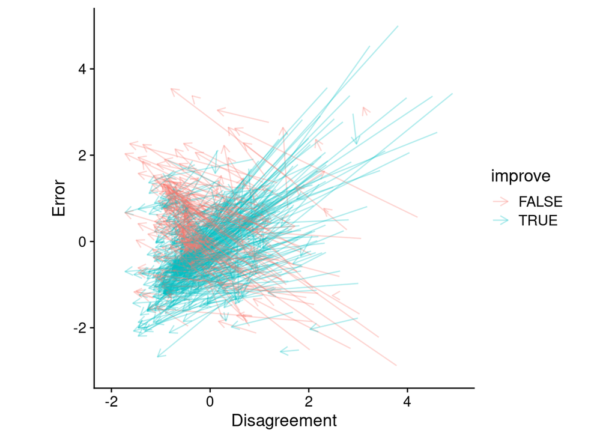

Figure 5: Movement of each group pre/post discussion, in normalised diagreement-error space, highlighting groups which improve or degrade in accruacy following discussion

```r
arrow_graph_accuracy_n <- ggplot() +
  geom_segment(aes(x = sd1, y = aee1, xend = sd2, yend = aee2, colour = improve), data = group_data_n, arrow = arrow(length=unit(0.1,"inches")), alpha = 0.3) +
  theme_cowplot() + xlab('Disagreement') + ylab('Error') + ylim(-3, 5) + xlim(-2, 5) + theme(aspect.ratio=1)
```

# Colophon

Repo: https://github.com/Lingyu-Meng/convergence-valence_space

*Thanks to Nick Byrd for discussion*